# predictive_modelling_deep_learning

```python
#https://stackoverflow.com/questions/27934885/how-to-hide-code-from-cells-in-ipython-notebook-visualized-with-nbviewer
#cool code for a button to hide code
from IPython.display import HTML

HTML('''<script>
code_show=true;
function code_toggle() {
 if (code_show){
 $('div.input').hide();
 } else {
 $('div.input').show();
 }
 code_show = !code_show
}
$( document ).ready(code_toggle);
</script>
<form action="javascript:code_toggle()"><input type="submit" value="Click here to toggle on/off the raw code."></form>''')
```

```python
import keras
from keras.layers import Dense
from keras.models import Sequential
import pandas as pd
import seaborn as sns
import matplotlib
import matplotlib.pyplot as plt
import numpy as np
```

### Titanic Deep Learning prediction

So now we are going to go for a basic deep learning model - as my current understanding is also basic. Being that we've already explored the variables extensively previously, we will just run the same cleaning code etc. And get right into setting up for our neural network.

```python
train = pd.read_csv("train.csv")
test = pd.read_csv("test.csv")

# clean nulls etc.

#replace null values with random samples from distr
def resample_age_values(df):
    mean = np.mean(df['Age'])
    std = np.std(df['Age'])

    rand_age = np.random.randint(mean - std, mean + std, size = df['Age'].isnull().sum())
    age_slice = df["Age"].copy()
    age_slice[np.isnan(age_slice)] = rand_age
    df["Age"] = age_slice
    df["Age"] = df["Age"].astype(int)

resample_age_values(train)
resample_age_values(test)

common = train['Embarked'].describe().top
train['Embarked'] = train['Embarked'].fillna(common)
common = test['Embarked'].describe().top
test['Embarked'] = test['Embarked'].fillna(common)
```

```python
#test.isna().sum()
```

```python
med = test['Fare'].describe()['50%']
test['Fare'] = test['Fare'].fillna(med)
```

```python
#test.isna().sum()
```

If you do look into some of this code, you will notice how we need to convert all our non continous variables to categorical matrices for the model. This can be easily done to our prediction classification 'survived' using to_categorical() from the keras library.

Then we can conveniently use the sklearn.preprocessing library to convert some of our other variables to categorical labels.

```python
# Train -------------------------

factors = list(train.columns)
factors.remove('Cabin')
factors.remove('Ticket')
factors.remove('Name')
factors.remove('PassengerId')

#set up valuesand target
model_df = train[factors].copy()
Y = model_df['Survived'].values
# we are going to use the 'categorical_crossentropy' loss function, which requires this format
from keras.utils import to_categorical
Y = to_categorical(Y)



factors.remove('Survived')
model_df = train[factors].copy()
X = model_df.values

# Test --------------------------

model_df = test[factors].copy()
X_test = model_df.values
```

```python
#model_df.dtypes
```

[output not shown]

```python
factors
```

```
['Pclass', 'Sex', 'Age', 'SibSp', 'Parch', 'Fare', 'Embarked']
```

```python
from sklearn.preprocessing import LabelEncoder, OrdinalEncoder

# Class, SibSp & Parch already encoded

# ----------- TRAIN ------------------

# Encode Sex
labelencoder_X_1 = LabelEncoder()
X[:, 1] = labelencoder_X_1.fit_transform(X[:, 1])

# Encode Embarked
labelencoder_X_2 = LabelEncoder()
X[:, 6] = labelencoder_X_2.fit_transform(X[:, 6].astype(str))

# ----------- TEST --------------------

# Encode Sex
labelencoder_Xtest_1 = LabelEncoder()
X_test[:, 1] = labelencoder_Xtest_1.fit_transform(X_test[:, 1])

# Encode Embarked
labelencoder_Xtest_2 = LabelEncoder()
X_test[:, 6] = labelencoder_Xtest_2.fit_transform(X_test[:, 6].astype(str))
print('Variables in categorical form')
X
```

```
Variables in categorical form
```

```
array([[3, 1, 22, ..., 0, 7.25, 2],
       [1, 0, 38, ..., 0, 71.2833, 0],
       [3, 0, 26, ..., 0, 7.925, 2],
       ...,
       [3, 0, 29, ..., 2, 23.45, 2],
       [1, 1, 26, ..., 0, 30.0, 0],
       [3, 1, 32, ..., 0, 7.75, 1]], dtype=object)
```

The sklearn.preprocessing library lets us easily normalize our data. This prevents the model from given excessive weight to larger continous variable numbers (e.g. Large 'Fare' entries).

```python
#scaling data
from sklearn.preprocessing import StandardScaler
sc = StandardScaler()
X = sc.fit_transform(X)
sc2 = StandardScaler()
X_test = sc2.fit_transform(X_test)
print('Normalized variables')
X_test
```

```
Normalized variables
```

```
array([[ 0.87348191,  0.75592895,  0.30020061, ..., -0.4002477 ,
        -0.49741333, -0.47091535],
       [ 0.87348191, -1.32287566,  1.28766436, ..., -0.4002477 ,
        -0.51227801,  0.70076689],
       [-0.31581919,  0.75592895,  2.42704561, ..., -0.4002477 ,
        -0.46410047, -0.47091535],
       ...,
       [ 0.87348191,  0.75592895,  0.60403561, ..., -0.4002477 ,
        -0.50779638,  0.70076689],
       [ 0.87348191,  0.75592895, -0.83918064, ..., -0.4002477 ,
        -0.49345515,  0.70076689],
       [ 0.87348191,  0.75592895,  0.60403561, ...,  0.61989583,
        -0.23695704, -1.64259759]])
```

```python
# Save the number of columns in predictors: n_cols
n_cols = X.shape[1]
```

So after having quickly run a model, I wanted to actually try and optimize our network based on number of hidden layers and the numbers in each layer. So I've created function to set up each model, and then looped through and iterative over some arbitrary sizes and numbers:

```
layers_trial = [1, 1, 1, 1, 1, 2, 2, 2, 2, 2]
layers_numbers = [[50], [100], [250], [500], [1000],
                 [250, 50], [250, 100], [250, 250], [500, 250], [1000, 500]]
```

I'm going to run these models with a few settings:

- An Early stopping monitor with an arbitrary level of 3. That is, if there are no greater improvements in the 'loss function' after 3 tries the network will finish
- I am using the optimizer 'sgd'
- Loss funciton 'categorical_crossentropy'
- An Epoch limit of 30
- And a validation split of 0.3, that is the model will use 70% of the data on training, and test it on 30%
- All Activation functions will arbitrarily be 'relu'

Many of these functions are because my understanding is still basic, I will look to learn how to tweak and optimize these in the future.

```python
'''runs model with set layer number and density per layer
    returns model training history'''
def create_model(layer_num, density_arr):
    early_stopping_monitor = EarlyStopping(patience=3)

    # ----------- Model 1 ----------------------

    # Set up the model: model
    model = Sequential()

    # Add the first layer
    model.add(Dense(density_arr[0], activation='relu', input_shape=(n_cols,)))

    if layer_num > 1:
        for i in range(1, layer_num):
            # Add the second layer
           # print(density_arr)
            #print(i)
            model.add(Dense(density_arr[i], activation='relu'))

    # Add the output layer
    model.add(Dense(2, activation='softmax'))

    # Compile the model
    model.compile(optimizer='sgd',
                  loss='categorical_crossentropy',
                  metrics=['accuracy'])
        # Fit the model
    return model.fit(X, Y, epochs=30, validation_split=0.3, callbacks=[early_stopping_monitor], verbose=False)
```

```python
layers_trial = [1, 1, 1, 1, 1, 2, 2, 2, 2, 2]
layers_numbers = [[50], [100], [250], [500], [1000],
                 [250, 50], [250, 100], [250, 250], [500, 250], [1000, 500]]
model_train_list = list()
for i in range(0, len(layers_trial)-1):
    #print(i)
    mt = create_model(layers_trial[i], layers_numbers[i])
    model_train_list.append(mt)

print('Models complete')
```

```
Models complete
```

```python
colours = matplotlib.colors.TABLEAU_COLORS
#colours = colours.keys
colours = [*colours.keys()]
```

```
Value loss
```

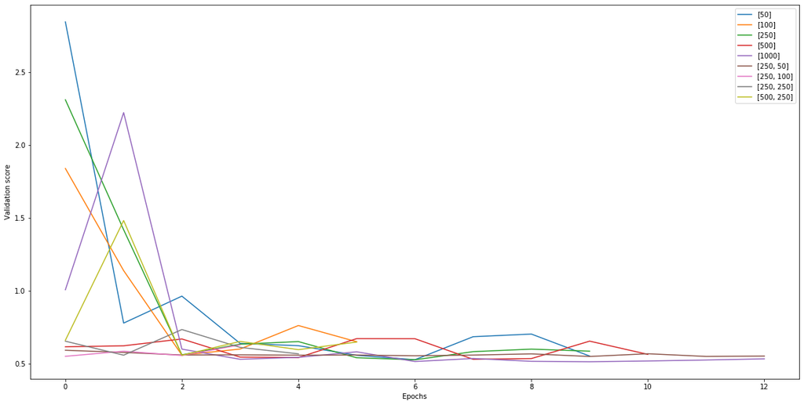

```python
print('Value loss')
for i in range(0, len(model_train_list)):
    hist = model_train_list[i]
    #print(i.history['val_loss'])
    vals = hist.history['val_loss']
    plt.plot(vals, colours[i], label=str(layers_numbers[i]))

plt.rcParams["figure.figsize"] = [20, 10]
plt.xlabel('Epochs')
plt.ylabel('Validation score')
plt.legend()
plt.show()
```

```
Accuracy
```

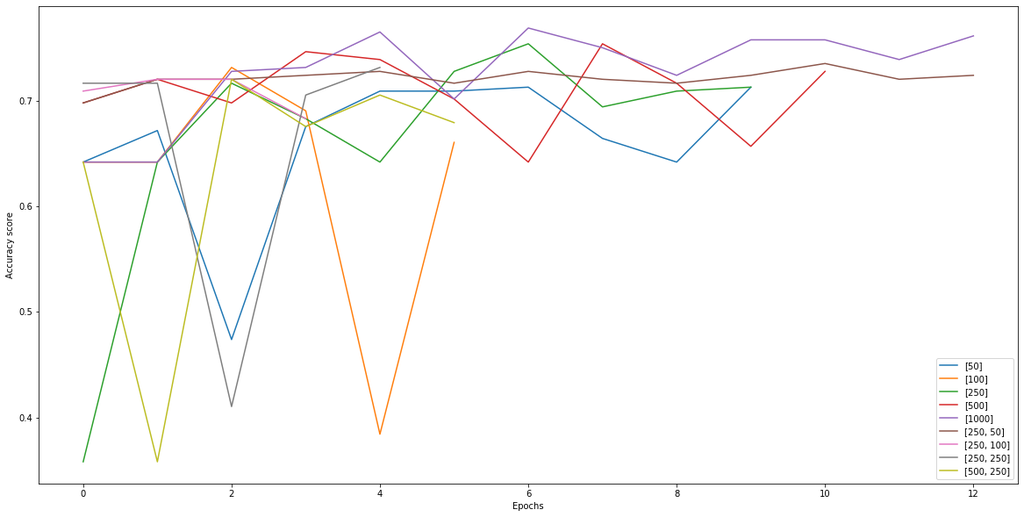

```python
print('Accuracy')
for i in range(0, len(model_train_list)):
    hist = model_train_list[i]
    #print(i.history['val_loss'])
    vals = hist.history['val_accuracy']
    plt.plot(vals, colours[i], label=str(layers_numbers[i]))

plt.rcParams["figure.figsize"] = [20, 10]
plt.xlabel('Epochs')
plt.ylabel('Accuracy score')
plt.legend()
plt.show()
```

We can peruse these charts and see which models did best, particularly looking at the accuracy. In this set it appears that our single hidden layer with 1000 nodes (purple), is particularly consistent at the top.

Next I will arbitrarily increase all these node numbers by a 10-fold increase.

```python
layers_trial = [1, 1, 1, 1, 1, 2, 2, 2, 2, 2]
layers_numbers = [[50], [100], [250], [500], [1000],
                 [250, 50], [250, 100], [250, 250], [500, 250], [1000, 500]]

#increase each by 10 fold
layers_numbers = [[j*10 for j in i] for i in layers_numbers ]

model_train_list2 = list()
for i in range(0, len(layers_trial)-1):
    #print(i)
    mt = create_model(layers_trial[i], layers_numbers[i])
    model_train_list2.append(mt)

print('Models complete')
```

```
Models complete
```

```
Value loss
```

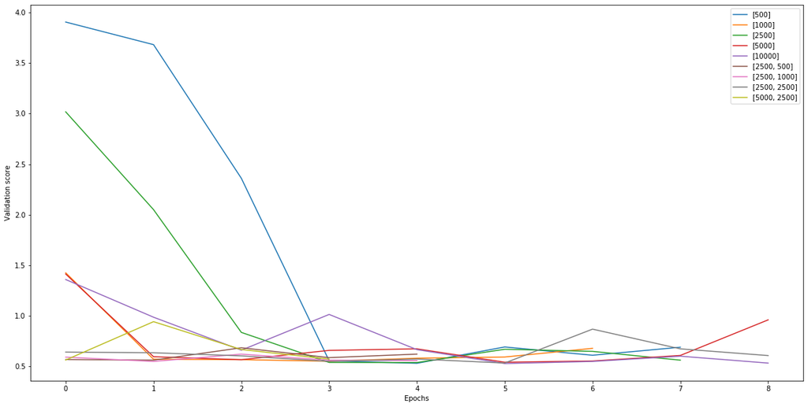

```python
print('Value loss')
for i in range(0, len(model_train_list2)):
    hist = model_train_list2[i]
    #print(i.history['val_loss'])
    vals = hist.history['val_loss']
    plt.plot(vals, colours[i], label=str(layers_numbers[i]))

plt.rcParams["figure.figsize"] = [20, 10]
plt.xlabel('Epochs')
plt.ylabel('Validation score')
plt.legend()
plt.show()
```

```
Accuracy
```

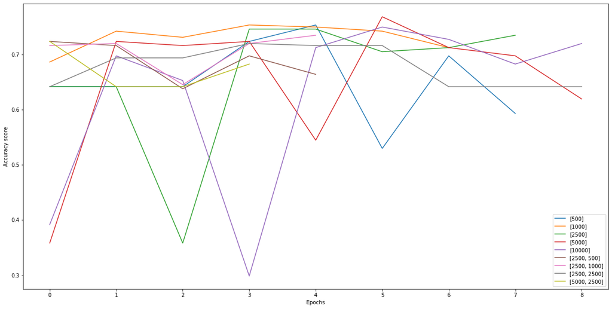

```python
print('Accuracy')
for i in range(0, len(model_train_list2)):
    hist = model_train_list2[i]
    #print(i.history['val_loss'])
    vals = hist.history['val_accuracy']
    plt.plot(vals, colours[i], label=str(layers_numbers[i]))

plt.rcParams["figure.figsize"] = [20, 10]
plt.xlabel('Epochs')
plt.ylabel('Accuracy score')
plt.legend()
plt.show()
```

Quite frankly we don't see any more improvements, if anything, less consistency than our earlier 1-layer with 1000 nodes. Therefore we will go with that model, and use it to predict in the kaggle competition.

```python
# chosen model
early_stopping_monitor = EarlyStopping(patience=3)

# ----------- Model 1 ----------------------

# Set up the model: model
model = Sequential()

# Add the first layer
model.add(Dense(1000, activation='relu', input_shape=(n_cols,)))


# Add the output layer
model.add(Dense(2, activation='softmax'))

# Compile the model
model.compile(optimizer='sgd',
              loss='categorical_crossentropy',
              metrics=['accuracy'])


# Fit the model
model_training = model.fit(X, Y, epochs=30, validation_split=0.3, callbacks=[early_stopping_monitor], verbose=False)
```

```python
predictions = model.predict(X_test)
```

```python
survivals = (predictions[:,1] >= 0.5).astype(int)
```

```python
test['Survived'] = survivals
test_file = test[['PassengerId', 'Survived']]
test_file.to_csv('submission_deeplearning.csv', header=True, index=False)
```

Sumbitting this to Kaggle we end up with a score of 0.76555. Pretty much what the figure showed us when we eye-ball the graph for our most optimal accuracy. Again ironically, this model can't compete with the very simple glm model we constructed (In a way this is a win for good exploration and statistical significance, which we used to inform our simple model).

Now that I've gotten a model running on this, I will come back next time and try to do some more optimizing and maybe find another feature. I will first develop more understanding on how to design good models, and hopefully come back and beat this score!